# Mortgage Payment Size and Default

# 1 Data

## 1.1 Data Sources

- Freddie Mac’s Single Family Loan-Level Dataset (Downloaded in November 2016) (http://www.freddiemac.com/news/finance/sf_loanlevel_dataset.html).
- Origination data cleaning: https://github.com/dimuthu999/strategic_default/blob/master/Create%20Origination%20Data.R
- Performance data cleaning: https://github.com/dimuthu999/strategic_default/blob/master/Apr2017_create_performance_rds.R
- Zillow’s ZHVI Single-Family Homes Time Series (http://files.zillowstatic.com/research/public/Zip/Zip_Zhvi_SingleFamilyResidence.csv)
- Zillow’s Median Rent List Price ($), Single-Family Residence (http://files.zillowstatic.com/research/public/Zip/Zip_MedianRentalPrice_Sfr.csv)
- 30-Year Fixed Rate Mortgage Average in the United States (https://fred.stlouisfed.org/series/MORTGAGE30US)
- 10-Year Treasury Constant Maturity Rate (https://fred.stlouisfed.org/series/GS10)
- Zip code level mean property tax rates (https://taxfoundation.org/data/)

## 1.2 Sample Construction

- Only include mortgages that satisfy the following criteria. 30 year, fixed rate, single family, owner occupied and new purchases. We exclude the loans that were modified.
- Using the ZHVI indices, calculate home equity for every borrower for every month
- Identify the time at which each borrower’s equity **first** drops below a certain threshold (-10%, -20%,…, -50%).
- Observe the following 12 months after reaching the threshold and identify the mortgages that went in to 60 day delinquency or prepaid during this 12 months
- Code used to create the negative equity samples are available at https://github.com/dimuthu999/strategic_default/blob/master/Apr2017_Create_NE_Samples.R
- Monthly mortgage payment was calculated using loan amount, loan term and interest rate. Mortgage payment was adjusted to include the property tax payments, maintainance cost (1% of value per year) and tax savings on interest (assuming a 20% income tax rate)
- Time to complete foreclosure was calculated for each zip code-year by using the foreclosures completed in each zip code-year (Code: https://github.com/dimuthu999/strategic_default/blob/master/Apr2017_create_foreclosuretime_rds.R)
- Positive equity samples were constructed using the same method. i.e. a mortgage enteres in to the positive equity sample when it first reaches the threshold from below. Code : https://github.com/dimuthu999/strategic_default/blob/master/Apr2017_Create_PE_Samples.R

# 2 Descriptive Statistics

Panel A provides descriptive statistics of the 30% negative equity sample. Panel B provides descriptive statistics of 30% positive equity sample.

## 2.1 Panel A: 30% Negative Equity

```
##
## ================================================================================
## Statistic        Mean        St. Dev.   Pctl(25)    Median     Pctl(75)     N
## --------------------------------------------------------------------------------
## def             0.05386      0.22575        0          0           0      45,282
## prepaid         0.10920      0.31190        0          0           0      45,282
## mpay_value      0.00850      0.00045     0.00823    0.00849     0.00877   45,282
## rent_value      0.00889      0.00237     0.00778    0.00831     0.00934   31,331
## fico           726.99100     52.18561      690        732         769     45,251
## mpay          1,367.01600   550.09690   940.51480 1,286.64900 1,737.41800 45,282
## ltv            90.42821      8.49339       80         95          95      45,282
## dti            38.56706      10.83262      31         39          46      44,431
## upb          207,548.30000 85,329.15000  141,000    195,000     265,000   45,282
## interestrate    6.24221      0.48238     5.87500    6.25000     6.50000   45,282
## org_year      2,006.30600    1.30834      2,005      2,006       2,007    45,282
## ne_year       2,009.76000    1.19936      2,009      2,010       2,011    45,282
## --------------------------------------------------------------------------------
##
```

## 2.2 Panel B: 30% Positive Equity

```
##
## ==============================================================================
## Statistic        Mean        St. Dev.   Pctl(25)   Median    Pctl(75)     N
## ------------------------------------------------------------------------------
## def             0.01633      0.12674        0         0          0      49,112
## prepaid         0.30294      0.45953        0         0          1      49,112
## mpay_value      0.00464      0.00046     0.00428   0.00462    0.00491   49,112
## rent_value      0.00805      0.00188     0.00696   0.00806    0.00915   18,010
## fico           711.61680     53.89119      672       716        755     49,112
## mpay           911.76180    389.13200   615.19930 848.33120 1,147.92100 49,112
## ltv            89.86671      6.09941       85        90         95      49,112
## dti            34.89935      10.21936      28        35         42      49,112
## upb          144,935.80000 64,621.03000  96,000    134,000    183,000   49,112
## interestrate    6.54732      0.86692     5.87500   6.50000    7.12500   49,112
## org_year      2,001.97700    2.33887      2,000     2,002      2,003    49,112
## ne_year       2,004.76100    2.73313      2,003     2,005      2,006    49,112
## ------------------------------------------------------------------------------
##
```

## 2.3 Negative Equity sample summary

```
##
## ==========================================================
##   ne_cutoff mortgage_to_value default_rate prepayment_rate
## ----------------------------------------------------------
## 1  -0.500         0.951          6.338          9.641
## 2  -0.400         0.918          6.064          9.818
## 3  -0.300         0.850          5.386         10.920
## 4  -0.200         0.782          4.544         12.489
## 5  -0.100         0.711          3.783         14.449
## ----------------------------------------------------------
## In percent
```

Back to top

# 3 NEGATIVE EQUITY

## 3.1 Default OLS

```
##
## ===================================================================
##                              Y: default ; iv: none
##              ------------------------------------------------------
##
##                 (1)        (2)        (3)        (4)        (5)
## -------------------------------------------------------------------
## fico         -0.0003*** -0.0003*** -0.0003*** -0.0003*** -0.0002***
##              (0.00001)  (0.00002)  (0.00002)  (0.00003)  (0.00004)
## ltv           0.004***   0.004***   0.004***   0.003***   0.002***
##               (0.0003)   (0.0004)   (0.001)    (0.001)    (0.0004)
## log(upb)      0.012***   0.016***   0.021***   0.025***   0.027***
##               (0.002)    (0.002)    (0.004)    (0.005)    (0.005)
## dti           0.001***   0.001***   0.001***   0.001***   0.001***
##               (0.0001)   (0.0001)   (0.0001)   (0.0002)   (0.0002)
## mpay_value   119.742*** 119.412*** 127.511*** 120.923*** 108.144***
##               (4.837)    (5.851)    (5.972)    (7.523)    (7.429)
## -------------------------------------------------------------------
##
## Observations  135,392     75,095     44,401     26,452     20,870
## Adjusted R2    0.117      0.106      0.117      0.118      0.122
## ===================================================================
## Note:                                   *p<0.1; **p<0.05; ***p<0.01
##                        Fixed Effects: zip x ne year, zip x org year
##                          Standard Errors clustered by zip x ne year
```

Back to top

## 3.2 Negative Equity: First Stage

```
##
## ===================================================================
##                             Y: mpay value ; iv: none
##              ------------------------------------------------------
##
##                 (1)        (2)        (3)        (4)        (5)
## -------------------------------------------------------------------
## mtg30us      49.344***  54.551***  59.365***  65.950***  68.768***
##               (0.508)    (0.732)    (0.941)    (1.226)    (2.312)
## fico         -0.076***  -0.079***  -0.079***  -0.081***  -0.086***
##               (0.002)    (0.003)    (0.004)    (0.005)    (0.006)
## ltv           0.837***   0.977***   1.017***   1.231***   1.169***
##               (0.043)    (0.052)    (0.067)    (0.080)    (0.109)
## log(upb)     -13.471*** -14.157*** -15.390*** -16.533*** -18.443***
##               (0.281)    (0.389)    (0.506)    (0.691)    (0.920)
## dti           0.059***   0.061***   0.039***    0.023     0.081***
##               (0.007)    (0.012)    (0.014)    (0.021)    (0.027)
## -------------------------------------------------------------------
##
## Observations  135,392     75,095     44,401     26,452     20,870
## Adjusted R2    0.637      0.557      0.518      0.518      0.477
## ===================================================================
## Note:                                   *p<0.1; **p<0.05; ***p<0.01
##                        Fixed Effects: zip x ne year, zip x org year
##                          Standard Errors clustered by zip x ne year
```

Back to top

## 3.3 Univariate Evidence - Nadaraya–Watson (30% Negative equity sample)

- FE adjusted mortgage-to-value = mortgage-to-value - predicted mortgage-to-value from (mortgage-to-value~ zip * ne year + zip * org year)
- Results are similar for other levels of negative equity

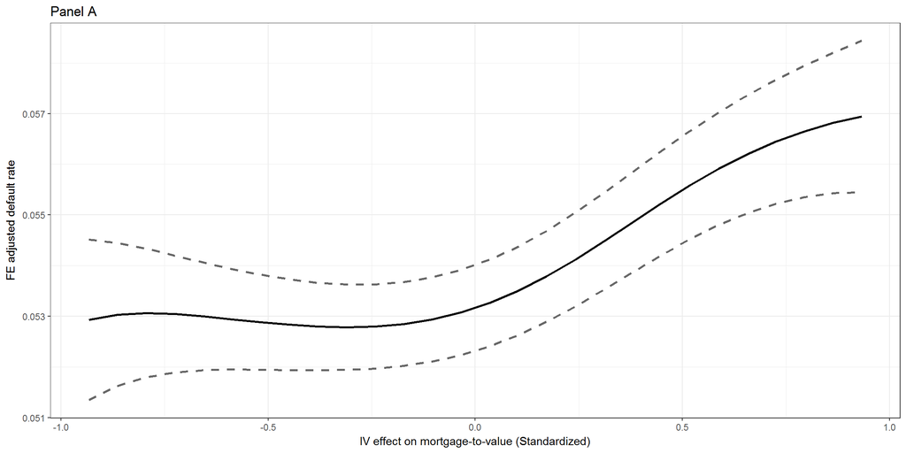

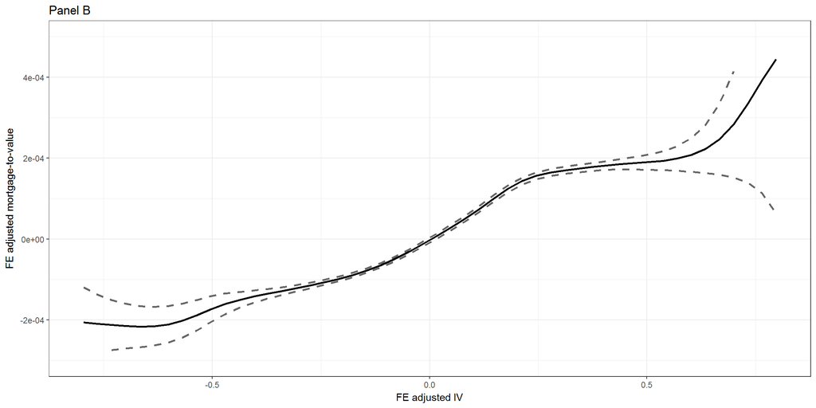

Back to top

## 3.4 Negative Equity: IV Regressions

```
##
## ========================================================================
##                                  Y: default ; iv: mtg30us
##                   ------------------------------------------------------
##
##                      (1)        (2)        (3)        (4)        (5)
## ------------------------------------------------------------------------
## fico              -0.0003*** -0.0003*** -0.0004*** -0.0004*** -0.0003***
##                   (0.00002)  (0.00002)  (0.00003)  (0.00004)  (0.00004)
## ltv                0.004***   0.005***   0.005***   0.005***   0.003***
##                    (0.0004)   (0.0004)   (0.001)    (0.001)    (0.0004)
## log(upb)            -0.001     0.003      0.004      0.007      0.010*
##                    (0.002)    (0.003)    (0.004)    (0.005)    (0.005)
## dti                0.001***   0.001***   0.001***   0.001***   0.001***
##                    (0.0001)   (0.0001)   (0.0001)   (0.0002)   (0.0002)
## `mpay_value(fit)` 29.679***  31.602***  22.388***   20.259**  23.372***
##                    (4.963)    (6.918)    (8.125)    (10.169)   (8.377)
## ------------------------------------------------------------------------
## Cond. F. Stat      1837.32    1100.68     842.3      516.97     226.43
## Observations       135,392     75,095     44,401     26,452     20,870
## Adjusted R2         0.099      0.088      0.093      0.095      0.103
## ========================================================================
## Note:                                        *p<0.1; **p<0.05; ***p<0.01
##                             Fixed Effects: zip x ne year, zip x org year
##                               Standard Errors clustered by zip x ne year
```

Back to top

## 3.5 Negative Equity: IV Regressions (Treasury Bond Rate)

```
##
## ========================================================================
##                                  Y: default ; iv: mtg30us
##                   ------------------------------------------------------
##
##                      (1)        (2)        (3)        (4)        (5)
## ------------------------------------------------------------------------
## fico              -0.0003*** -0.0003*** -0.0004*** -0.0003*** -0.0003***
##                   (0.00002)  (0.00002)  (0.00003)  (0.00004)  (0.00004)
## ltv                0.004***   0.005***   0.005***   0.004***   0.003***
##                    (0.0004)   (0.0004)   (0.001)    (0.001)    (0.0004)
## log(upb)           -0.0003    0.006**     0.007*    0.014***   0.013**
##                    (0.002)    (0.003)    (0.004)    (0.005)    (0.006)
## dti                0.001***   0.001***   0.001***   0.001***   0.001***
##                    (0.0001)   (0.0001)   (0.0001)   (0.0002)   (0.0002)
## `mpay_value(fit)` 33.595***  51.391***  44.647***  56.095***  34.987***
##                    (7.224)    (10.234)   (12.164)   (14.657)   (11.037)
## ------------------------------------------------------------------------
## Cond. F. Stat       799.74     518.8      292.69     219.07     164.05
## Observations       135,392     75,095     44,401     26,452     20,870
## Adjusted R2         0.100      0.095      0.102      0.109      0.107
## ========================================================================
## Note:                                        *p<0.1; **p<0.05; ***p<0.01
##                             Fixed Effects: zip x ne year, zip x org year
##                               Standard Errors clustered by zip x ne year
```

## 3.6 Split by FICO (20% NE Sample)

```
##
## =================================================================
##                              Y: default ; iv: mtg30us
##                   -----------------------------------------------
##                     Q1 - 662    Q2 - 712    Q3 - 752    Q4 - 787
##                       (1)          (2)         (3)        (4)
## -----------------------------------------------------------------
## fico               -0.0004***   -0.0003**   -0.001***   -0.00002
##                     (0.0001)    (0.0001)    (0.0001)    (0.0001)
## ltv                 0.008***    0.005***    0.004***    0.002***
##                     (0.001)     (0.0004)    (0.0003)    (0.0003)
## log(upb)             0.007        0.007      -0.005      0.002
##                     (0.006)      (0.005)     (0.004)    (0.003)
## dti                 0.001***    0.001***    0.0005***  0.0004***
##                     (0.0002)    (0.0001)    (0.0001)    (0.0001)
## `mpay_value(fit)`  46.563***    33.723***    14.802    23.857***
##                     (15.307)    (12.318)    (10.885)    (8.805)
## -----------------------------------------------------------------
##
## Observations         18,886      18,849      18,844      18,516
## Adjusted R2          0.092        0.098       0.070      0.073
## =================================================================
## Note:                                 *p<0.1; **p<0.05; ***p<0.01
##                      Fixed Effects: zip x ne year, zip x org year
##                        Standard Errors clustered by zip x ne year
```

## 3.7 Graphical Illustration

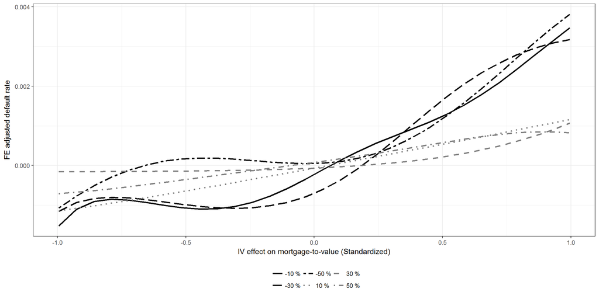

# 4 Control Variables

```
##
## ==========================================================================================================
##                                                             Dependent variable:
##                                  -------------------------------------------------------------------------
##                                                   paste(variable, formula_text, sep = "")
##                                  log(ltv)  log(upb) log(fico) log(dti) log(currenthousevalue) interestdiff
##                                     (1)      (2)       (3)      (4)             (5)               (6)
## ----------------------------------------------------------------------------------------------------------
## `std_mpay_value(fit)`            -0.011*** -0.018**   0.001   0.027***         -0.011          -0.192***
##                                   (0.002)  (0.007)   (0.001)  (0.005)         (0.007)           (0.010)
## ----------------------------------------------------------------------------------------------------------
## Observations                      44,401    44,401   44,401    44,401          44,401            44,401
## R2                                 0.738    0.393     0.053    0.049           0.405             -0.541
## Adjusted R2                        0.730    0.377     0.027    0.023           0.389             -0.584
## Residual Std. Error (df = 43219)   0.051    0.345     0.073    0.316           0.346             0.460
## ==========================================================================================================
## Note:                                                                          *p<0.1; **p<0.05; ***p<0.01
##                                                               Fixed Effects: zip x ne year, zip x org year
##                                                                 Standard Errors clustered by zip x ne year
```

Back to top

# 5 STRATEGIC DEFAULT

## 5.1 Rent Regressions

### 5.1.1 log(rent) ~ log(home_price)

```
##
## ============================================================================
##                                       Dependent variable:
##                     --------------------------------------------------------
##                                           formula_list
##                            (1)                (2)                (3)
## ----------------------------------------------------------------------------
## log(home_price)          0.528***           0.535***           0.047***
##                          (0.002)            (0.002)            (0.002)
## Constant                 0.853***
##                          (0.021)
## ----------------------------------------------------------------------------
## year                        No                 No                 No
## zip                         No                 No                 No
## ----------------------------------------------------------------------------
## Observations              37,475             37,475             37,475
## R2                        0.711              0.715              0.982
## Adjusted R2               0.711              0.715              0.982
## Residual Std. Error 0.187 (df = 37473) 0.186 (df = 37467) 0.047 (df = 36606)
## ============================================================================
## Note:                                            *p<0.1; **p<0.05; ***p<0.01
```

### 5.1.2 log(rent(t) - rent(t-6)) ~ log(homeprice(t) - homeprice(t-6))

year and zip fixed effects

```
##
## ============================================================================
##                                       Dependent variable:
##                     --------------------------------------------------------
##                                           formula_list
##                            All          Price Decreases    Price Increases
##                            (1)                (2)                (3)
## ----------------------------------------------------------------------------
## price_diff               0.018***            0.006*            0.013***
##                          (0.002)            (0.004)            (0.003)
## ----------------------------------------------------------------------------
## Observations              37,475             13,502             23,962
## R2                        0.057              0.133              0.085
## Adjusted R2               0.035              0.075              0.051
## Residual Std. Error 0.060 (df = 36606) 0.060 (df = 12650) 0.059 (df = 23098)
## ============================================================================
## Note:                                            *p<0.1; **p<0.05; ***p<0.01
```

### 5.1.3 log(rent) ~ log(home_price) : Split by value

year and zip fixed effects

```
##
## =========================================================
##                              Dependent variable:
##                     -------------------------------------
##                                 formula_list
##                     High Value Houses   Low Value Houses
##                            (1)                (2)
## ---------------------------------------------------------
## log(home_price)          0.080***           0.028***
##                          (0.004)            (0.002)
## ---------------------------------------------------------
## Observations              18,402             18,958
## R2                        0.979              0.962
## Adjusted R2               0.979              0.961
## Residual Std. Error 0.049 (df = 17967) 0.044 (df = 18522)
## =========================================================
## Note:                         *p<0.1; **p<0.05; ***p<0.01
```

## 5.2 Negative Equity: OLS (mpayvalue*rent)

```
##
## ====================================================================
##                               Y: default ; iv: none
##               ------------------------------------------------------
##
##                  (1)        (2)        (3)        (4)        (5)
## --------------------------------------------------------------------
## fico          -0.0003*** -0.0003*** -0.0004*** -0.0003*** -0.0003***
##               (0.00004)  (0.00004)   (0.0001)   (0.0001)   (0.0001)
## ltv            0.002***   0.004***   0.006***   0.007***   0.003***
##                (0.001)    (0.001)    (0.001)    (0.001)    (0.001)
## log(upb)        0.001      -0.006     0.0004    -0.0002     0.011
##                (0.005)    (0.006)    (0.008)    (0.012)    (0.012)
## dti            0.001***   0.0005**    0.0003     0.0002    0.001***
##                (0.0002)   (0.0002)   (0.0002)   (0.0003)   (0.0004)
## `m_to_r(fit)`  0.527***   0.348***    0.306*    0.509**     0.460*
##                (0.108)    (0.116)    (0.175)    (0.254)    (0.238)
## --------------------------------------------------------------------
##
## Observations    13,805     10,364     7,873      5,215      4,335
## Adjusted R2     0.125      0.098      0.121      0.118      0.117
## ====================================================================
## Note:                                    *p<0.1; **p<0.05; ***p<0.01
##                         Fixed Effects: zip x ne year, zip x org year
##                           Standard Errors clustered by zip x ne year
```

Back to top

## 5.3 Negative Equity: IV Regressions (50-50 Split by rent-to-value)

```
##
## ========================================================================================================================================================
##                                                                          Y: default ; iv: mtg30us
##                   --------------------------------------------------------------------------------------------------------------------------------------
##                   10% low rent 10% high rent 20% low rent 20% high rent 30% low rent 30% high rent 40% low rent 40% high rent 50% low rent 50% high rent
##                       (1)           (2)          (3)           (4)          (5)           (6)          (7)           (8)          (9)          (10)
## --------------------------------------------------------------------------------------------------------------------------------------------------------
## fico               -0.0004***   -0.0003***    -0.0004***   -0.0003***    -0.0004***   -0.0005***    -0.0004***   -0.0005***    -0.0003***   -0.0003***
##                    (0.00003)     (0.00003)    (0.00003)     (0.00004)    (0.00004)     (0.0001)     (0.00005)     (0.0001)      (0.0001)     (0.0001)
## ltv                 0.004***     0.003***      0.005***     0.004***      0.005***     0.004***      0.005***     0.005***      0.003***     0.003***
##                     (0.001)       (0.001)      (0.001)       (0.001)      (0.001)       (0.001)      (0.001)       (0.001)      (0.001)       (0.001)
## log(upb)             -0.003        0.002        -0.004        0.007        0.001         0.012        0.010         0.004        0.013         0.015
##                     (0.004)       (0.004)      (0.004)       (0.005)      (0.006)       (0.009)      (0.008)       (0.009)      (0.009)       (0.011)
## dti                 0.001***     0.001***      0.001***     0.001***      0.001***     0.001***      0.001**       0.001**      0.001***     0.001***
##                     (0.0001)     (0.0001)      (0.0001)     (0.0002)      (0.0002)     (0.0002)      (0.0003)     (0.0002)      (0.0003)     (0.0002)
## `mpay_value(fit)`  29.640***     33.090***     23.054**      21.089       23.878**      26.383      49.885***      -27.799      28.523**       1.302
##                     (9.464)       (9.748)      (11.016)     (14.636)      (10.937)     (17.125)      (14.944)     (18.174)      (13.510)     (18.515)
## --------------------------------------------------------------------------------------------------------------------------------------------------------
##
## Observations         39,656       30,242        26,423       19,908        17,611       13,056        11,267        8,307        8,876         6,789
## Adjusted R2          0.090         0.083        0.072         0.074        0.087         0.089        0.098         0.069        0.116         0.078
## ========================================================================================================================================================
## Note:                                                                                                                        *p<0.1; **p<0.05; ***p<0.01
##                                                                                                             Fixed Effects: zip x ne year, zip x org year
##                                                                                                               Standard Errors clustered by zip x ne year
```

## 5.4 Negative Equity: IV Regressions (75-25 Split by rent-to-value)

```
##
## ========================================================================================================================================================
##                                                                          Y: default ; iv: mtg30us
##                   --------------------------------------------------------------------------------------------------------------------------------------
##                   10% low rent 10% high rent 20% low rent 20% high rent 30% low rent 30% high rent 40% low rent 40% high rent 50% low rent 50% high rent
##                       (1)           (2)          (3)           (4)          (5)           (6)          (7)           (8)          (9)          (10)
## --------------------------------------------------------------------------------------------------------------------------------------------------------
## fico               -0.0003***   -0.0004***    -0.0004***   -0.0004***    -0.0004***    -0.001***    -0.0003***    -0.001***    -0.0003***   -0.0004***
##                    (0.00003)     (0.00005)    (0.00003)     (0.0001)     (0.00004)     (0.0001)     (0.00004)     (0.0001)     (0.00005)     (0.0001)
## ltv                 0.004***     0.004***      0.004***     0.004***      0.005***      0.004**      0.005***      0.004**      0.003***      0.004**
##                     (0.0005)      (0.001)      (0.0005)      (0.001)      (0.001)       (0.002)      (0.001)       (0.002)      (0.0005)      (0.002)
## log(upb)             -0.001        0.004        -0.002       0.016*        0.001        0.031**       0.009        -0.001        0.011        0.027*
##                     (0.003)       (0.007)      (0.004)       (0.009)      (0.005)       (0.015)      (0.007)       (0.017)      (0.007)       (0.016)
## dti                 0.001***      0.0004       0.001***      0.001**      0.001***      0.0004       0.001***      0.0004       0.001***     0.001***
##                     (0.0001)     (0.0003)      (0.0001)     (0.0003)      (0.0001)     (0.0003)      (0.0002)     (0.0004)      (0.0002)     (0.0004)
## `mpay_value(fit)`  35.009***       9.576       21.106**      27.707       22.832**      35.652       27.284**      -28.617      21.475*       -2.703
##                     (7.429)      (18.957)      (9.729)      (22.839)      (10.161)     (27.687)      (12.548)     (33.158)      (11.356)     (30.684)
## --------------------------------------------------------------------------------------------------------------------------------------------------------
##
## Observations         58,519       11,379        38,992        7,339        25,638        5,029        16,334        3,240        13,039        2,626
## Adjusted R2          0.087         0.081        0.069         0.093        0.082         0.110        0.090         0.069        0.104         0.077
## ========================================================================================================================================================
## Note:                                                                                                                        *p<0.1; **p<0.05; ***p<0.01
##                                                                                                             Fixed Effects: zip x ne year, zip x org year
##                                                                                                               Standard Errors clustered by zip x ne year
```

Back to top

## 5.5 Foreclosure Delay

```
##
## ============================================================================
##                                       Y: default ; iv: none
##                       ------------------------------------------------------
##
##                          (1)        (2)        (3)        (4)        (5)
## ----------------------------------------------------------------------------
## months_in_foreclosure  0.002***   0.004***   0.006***   0.009***   0.007***
##                        (0.0003)   (0.0004)   (0.001)    (0.001)    (0.001)
## fico                  -0.0004*** -0.0004*** -0.0004*** -0.0004*** -0.0003***
##                       (0.00001)  (0.00001)  (0.00002)  (0.00003)  (0.00003)
## ltv                    0.001***   0.001***   0.001***   0.001***   0.001**
##                        (0.0001)   (0.0001)   (0.0001)   (0.0002)   (0.0002)
## log(upb)                -0.002     0.001      0.005*     0.006      0.005
##                        (0.001)    (0.002)    (0.003)    (0.004)    (0.005)
## dti                    0.001***   0.001***   0.001***   0.001***   0.001***
##                       (0.00005)   (0.0001)   (0.0001)   (0.0001)   (0.0002)
## ----------------------------------------------------------------------------
##
## Observations           133,845     74,730     44,291     26,372     20,817
## Adjusted R2             0.019      0.018      0.019      0.017      0.013
## ============================================================================
## Note:                                            *p<0.1; **p<0.05; ***p<0.01
##                                       Fixed Effects: State, Origination Year
```

## 5.6 Mortgage-to-value Foreclosure Delay split

```
##
## ========================================================================================================================================================
##                                                                          Y: default ; iv: mtg30us
##                   --------------------------------------------------------------------------------------------------------------------------------------
##                   10% low rent 10% high rent 20% low rent 20% high rent 30% low rent 30% high rent 40% low rent 40% high rent 50% low rent 50% high rent
##                       (1)           (2)          (3)           (4)          (5)           (6)          (7)           (8)          (9)          (10)
## --------------------------------------------------------------------------------------------------------------------------------------------------------
## fico               -0.0004***   -0.0003***    -0.0004***   -0.0003***    -0.0004***   -0.0004***    -0.0004***   -0.0003***    -0.0003***   -0.0003***
##                    (0.00003)     (0.00002)    (0.00003)     (0.00002)    (0.00004)     (0.00004)     (0.0001)     (0.00004)     (0.0001)     (0.0001)
## ltv                 0.004***     0.005***      0.004***     0.006***      0.004***     0.006***      0.004***     0.006***      0.003***     0.003***
##                     (0.0005)      (0.001)      (0.001)       (0.001)      (0.001)       (0.001)      (0.001)       (0.001)      (0.0005)      (0.001)
## log(upb)             0.005*       -0.004*      0.014***      -0.002       0.016***      -0.003       0.021***      0.0002        0.014*        0.009
##                     (0.003)       (0.002)      (0.004)       (0.003)      (0.005)       (0.005)      (0.007)       (0.006)      (0.008)       (0.007)
## dti                 0.001***     0.001***      0.001***     0.001***      0.001***     0.0005***     0.001***     0.001***      0.001***     0.001***
##                     (0.0001)     (0.0001)      (0.0001)     (0.0001)      (0.0002)     (0.0001)      (0.0002)     (0.0002)      (0.0002)     (0.0002)
## `mpay_value(fit)`  30.032***     29.940***      10.516      45.929***     28.697**     22.343**       18.452       24.830*      28.518*      23.884**
##                     (7.801)       (6.697)      (9.713)       (9.538)      (14.188)      (9.691)      (14.482)     (14.216)      (14.703)     (10.178)
## --------------------------------------------------------------------------------------------------------------------------------------------------------
##
## Observations         48,148       85,697        28,850       45,880        17,357       26,934        11,007       15,365        8,728        12,089
## Adjusted R2          0.090         0.110        0.061         0.107        0.070         0.112        0.060         0.119        0.071         0.124
## ========================================================================================================================================================
## Note:                                                                                                                        *p<0.1; **p<0.05; ***p<0.01
##                                                                                                             Fixed Effects: zip x ne year, zip x org year
##                                                                                                               Standard Errors clustered by zip x ne year
```

## 5.7 Judicial, Recourse States (20% Negative Equity)

```
##
## =========================================================================================================================
##                                                                   Y: Default ; iv: mtg30us
##                                     -------------------------------------------------------------------------------------
##                                        OLS    Non-judicial  Judicial  Non-recourse  Recourse  non-Jud, non-Rec  Jud,Rec
##                                        (1)        (2)         (3)         (4)         (5)           (6)           (7)
## -------------------------------------------------------------------------------------------------------------------------
## factor(judicial)1                   0.206***
##                                      (0.013)
## factor(recourse)1                   0.034***
##                                      (0.003)
## fico                                0.0003***  -0.0004***  -0.0003***  -0.0004***  -0.0003***    -0.0004***    -0.0003***
##                                     (0.00002)  (0.00002)   (0.00003)   (0.00003)   (0.00002)     (0.00003)     (0.00003)
## ltv                                 0.001***    0.004***    0.006***    0.004***    0.005***      0.004***      0.005***
##                                     (0.0002)    (0.0005)    (0.001)     (0.001)     (0.001)       (0.001)       (0.001)
## log(upb)                            0.053***    -0.0003      0.009*      0.009*      0.001        0.009**        0.010*
##                                      (0.003)    (0.003)     (0.005)     (0.005)     (0.003)       (0.005)       (0.005)
## dti                                 -0.001***   0.001***    0.001***    0.001***    0.001***      0.001***      0.001***
##                                     (0.0001)    (0.0001)    (0.0001)    (0.0001)    (0.0001)      (0.0001)      (0.0001)
## factor(judicial)1:factor(recourse)1 -0.201***
##                                      (0.013)
## `mpay_value(fit)`                              24.252***   48.591***    23.764*    36.041***      24.935*      50.345***
##                                                 (8.017)     (12.645)    (12.715)    (8.141)       (13.012)      (12.916)
## -------------------------------------------------------------------------------------------------------------------------
##
## Observations                         75,095      48,838      26,257      23,617      51,478        22,946        25,586
## Adjusted R2                           0.016      0.089       0.089       0.093       0.087         0.092         0.088
## =========================================================================================================================
## Note:                                                                                         *p<0.1; **p<0.05; ***p<0.01
##                                                                              Fixed Effects: zip x ne year, zip x org year
##                                                                                Standard Errors clustered by zip x ne year
```

Back to top

# 6 Negative Equity Prepayments

## 6.1 Negative Equity: Prepayments IV Regressions

```
##
## ====================================================================
##                              Y: prepayment ; iv: mtg30us
##                   --------------------------------------------------
##                      10%        20%       30%       40%       50%
##                      (1)        (2)       (3)       (4)       (5)
## --------------------------------------------------------------------
## fico              0.0004***  0.0004*** 0.0004*** 0.0003*** 0.0003***
##                   (0.00002)  (0.00003) (0.00003) (0.00004) (0.00005)
## ltv               -0.004***  -0.003*** -0.003*** -0.004*** -0.003***
##                    (0.0003)  (0.0004)  (0.0005)   (0.001)  (0.0005)
## log(upb)           0.107***  0.098***  0.100***  0.083***  0.080***
##                    (0.004)    (0.005)   (0.006)   (0.008)   (0.009)
## dti               -0.0005*** -0.001*** -0.001*** -0.0003** -0.0005**
##                    (0.0001)  (0.0001)  (0.0001)  (0.0002)  (0.0002)
## `mpay_value(fit)` 67.563***  51.409*** 45.795*** 53.313*** 55.125***
##                    (9.083)   (10.349)  (13.114)  (12.175)  (15.513)
## --------------------------------------------------------------------
## Cond. F. Stat      1837.32    1100.68    842.3    516.97    226.43
## Observations       135,392    75,095    44,401    26,452    20,870
## Adjusted R2         0.087      0.104     0.120     0.118     0.117
## ====================================================================
## Note:                                    *p<0.1; **p<0.05; ***p<0.01
##                         Fixed Effects: zip x ne year, zip x org year
##                           Standard Errors clustered by zip x ne year
```

## 6.2 Negative Equity: Prepayments IV Regressions (Split by rent-to-value)

```
##
## ========================================================================================================================================================
##                                                                        Y: Prepayment ; iv: mtg30us
##                   --------------------------------------------------------------------------------------------------------------------------------------
##                   10% low rent 10% high rent 20% low rent 20% high rent 30% low rent 30% high rent 40% low rent 40% high rent 50% low rent 50% high rent
##                       (1)           (2)          (3)           (4)          (5)           (6)          (7)           (8)          (9)          (10)
## --------------------------------------------------------------------------------------------------------------------------------------------------------
## fico               0.0004***     0.0004***    0.0003***     0.0003***    0.0003***     0.0003***    0.0003***     0.0003***    0.0003***     0.0002**
##                    (0.00005)     (0.00004)    (0.00004)     (0.0001)      (0.0001)     (0.0001)      (0.0001)     (0.0001)      (0.0001)     (0.0001)
## ltv                -0.004***     -0.003***    -0.003***     -0.002***    -0.003***     -0.003***    -0.003***     -0.003***    -0.003***     -0.002***
##                     (0.001)      (0.0005)      (0.001)       (0.001)      (0.001)       (0.001)      (0.001)       (0.001)      (0.001)       (0.001)
## log(upb)            0.090***     0.098***      0.093***     0.084***      0.093***     0.082***      0.076***     0.081***      0.084***     0.071***
##                     (0.008)       (0.008)      (0.008)       (0.011)      (0.009)       (0.013)      (0.010)       (0.016)      (0.013)       (0.017)
## dti                -0.0004***    -0.0003*     -0.001***     -0.001***     -0.0003       -0.0002      -0.00001     -0.001**      -0.00005     -0.001**
##                     (0.0001)     (0.0002)      (0.0002)     (0.0002)      (0.0002)     (0.0002)      (0.0002)     (0.0003)      (0.0003)     (0.0003)
## `mpay_value(fit)`  64.815***     42.459**     49.472***     43.857**       24.891      77.581***     44.472**     49.539**      64.904**      34.163*
##                     (13.991)     (18.535)      (18.158)     (18.688)      (23.627)     (18.439)      (17.790)     (20.445)      (28.181)     (18.125)
## --------------------------------------------------------------------------------------------------------------------------------------------------------
##
## Observations         39,656       30,242        26,423       19,908        17,611       13,056        11,267        8,307        8,876         6,789
## Adjusted R2          0.075         0.098        0.081         0.097        0.107         0.087        0.103         0.109        0.109         0.112
## ========================================================================================================================================================
## Note:                                                                                                                        *p<0.1; **p<0.05; ***p<0.01
##                                                                                                             Fixed Effects: zip x ne year, zip x org year
##                                                                                                               Standard Errors clustered by zip x ne year
```

Back to top

## 6.3 Negative Equity: IV Regressions (Split by origination year)

```
##
## ===============================================================
##                             Y: default ; iv: mtg30us
##                   ---------------------------------------------
##                           <=2006                  >2006
##                             (1)                    (2)
## ---------------------------------------------------------------
## fico                    -0.0003***             -0.0004***
##                          (0.00002)              (0.00003)
## ltv                      0.004***               0.007***
##                          (0.0004)                (0.001)
## log(upb)                   0.004                  0.001
##                           (0.004)                (0.003)
## dti                      0.0005***              0.001***
##                          (0.0001)               (0.0001)
## `mpay_value(fit)`        37.617***               18.522*
##                           (8.683)                (9.938)
## ---------------------------------------------------------------
##
## Observations              38,250                 36,845
## Adjusted R2                0.090                  0.093
## ===============================================================
## Note:                               *p<0.1; **p<0.05; ***p<0.01
##                    Fixed Effects: zip x ne year, zip x org year
##                      Standard Errors clustered by zip x ne year
```

# 7 POSITIVE EQUITY

## 7.1 Positive Equity: Default IV Regressions

```
##
## ================================================================
##                              Y: default ; iv: mtg30us
##                   ----------------------------------------------
##                         10              30              50
##                         (1)             (2)            (3)
## ----------------------------------------------------------------
## fico                -0.0002***      -0.0002***      -0.0002***
##                      (0.00002)       (0.00002)      (0.00001)
## ltv                  -0.001**        -0.002***      -0.002***
##                      (0.0004)        (0.0003)        (0.0002)
## log(upb)              -0.001          -0.002          -0.003
##                       (0.002)         (0.002)        (0.002)
## dti                   0.0001         0.0002**        0.0001*
##                      (0.0001)        (0.0001)       (0.00005)
## `mpay_value(fit)`      7.324           9.360          10.022
##                       (7.900)         (6.870)        (7.290)
## ----------------------------------------------------------------
## Cond. F. Stat         310.31          1227.45         551.94
## Observations          31,961          49,112          48,139
## Adjusted R2            0.182           0.064          0.010
## ================================================================
## Note:                                *p<0.1; **p<0.05; ***p<0.01
##                     Fixed Effects: zip x ne year, zip x org year
##                       Standard Errors clustered by zip x ne year
```

Back to top

## 7.2 Positive Equity: Prepayment IV Regressions

```
##
## ================================================================
##                              Y: Prepaid ; iv: mtg30us
##                   ----------------------------------------------
##                         10              30              50
##                         (1)             (2)            (3)
## ----------------------------------------------------------------
## fico                 0.0005***       0.0001**       -0.0003***
##                      (0.0001)        (0.00005)       (0.0001)
## ltv                  -0.005***       -0.004***      -0.009***
##                       (0.001)         (0.001)        (0.001)
## log(upb)             0.147***        0.134***        0.106***
##                       (0.009)         (0.008)        (0.008)
## dti                   0.0002          0.0003         0.001***
##                      (0.0002)        (0.0002)        (0.0002)
## `mpay_value(fit)`   167.372***      326.075***      390.731***
##                      (27.433)        (24.706)        (29.940)
## ----------------------------------------------------------------
## Cond. F. Stat         310.31          1227.45         551.94
## Observations          31,961          49,112          48,139
## Adjusted R2            0.108           0.167          0.163
## ================================================================
## Note:                                *p<0.1; **p<0.05; ***p<0.01
##                     Fixed Effects: zip x ne year, zip x org year
##                       Standard Errors clustered by zip x ne year
```

Back to top

## 7.3 Positive Equity Prepayments Rent Split

```
##
## ============================================================================================
##                                          Y: Prepayment ; iv: mtg30us
##                   --------------------------------------------------------------------------
##                   10 low rent 10 high rent 30 low rent 30 high rent 50 low rent 50 high rent
##                       (1)         (2)          (3)         (4)          (5)         (6)
## --------------------------------------------------------------------------------------------
## fico               0.0004**     0.001***    -0.00004     0.00001    -0.0003***   -0.0005***
##                    (0.0002)     (0.0001)    (0.0001)     (0.0001)    (0.0001)     (0.0001)
## ltv                 -0.003     -0.010***     -0.001      -0.004**    -0.009***   -0.008***
##                     (0.003)     (0.003)      (0.002)     (0.002)      (0.002)     (0.002)
## log(upb)           0.189***     0.187***    0.132***     0.154***    0.097***     0.101***
##                     (0.047)     (0.021)      (0.018)     (0.017)      (0.018)     (0.015)
## dti                 0.0001      -0.0001       0.001       0.0001      0.001**      0.0003
##                     (0.001)     (0.001)      (0.001)     (0.0005)    (0.0005)     (0.0004)
## `mpay_value(fit)`  150.229**   188.454***  361.180***   363.882***  435.117***   405.973***
##                    (71.613)     (55.697)    (55.220)     (50.118)    (60.417)     (56.441)
## --------------------------------------------------------------------------------------------
##
## Observations         2,672       4,975        8,377       9,633       10,581       10,903
## Adjusted R2          0.129       0.102        0.168       0.153        0.179       0.103
## ============================================================================================
## Note:                                                            *p<0.1; **p<0.05; ***p<0.01
##                                                 Fixed Effects: zip x ne year, zip x org year
##                                                   Standard Errors clustered by zip x ne year
```

# 8 Other Splits

## 8.1 First stage by year (NE 30%)

```
##
## ==========================================================
##                        Y: mpay value ; iv: none
##              ---------------------------------------------
##                      <=2006                 >=2007
##                        (1)                    (2)
## ----------------------------------------------------------
## mtg30us             61.304***              58.209***
##                      (1.518)                (1.264)
## fico                -0.044***              -0.117***
##                      (0.005)                (0.006)
## ltv                 0.986***               1.239***
##                      (0.091)                (0.097)
## log(upb)           -15.216***             -15.774***
##                      (0.693)                (0.719)
## dti                  -0.013                0.078***
##                      (0.020)                (0.021)
## ----------------------------------------------------------
##
## Observations         22,940                 21,461
## Adjusted R2           0.513                  0.513
## ==========================================================
## Note:                          *p<0.1; **p<0.05; ***p<0.01
##               Fixed Effects: zip x ne year, zip x org year
##                 Standard Errors clustered by zip x ne year
```

## 8.2 Control Variables <=2006

```
##
## ==========================================================================================================
##                                                             Dependent variable:
##                                  -------------------------------------------------------------------------
##                                                   paste(variable, formula_text, sep = "")
##                                  log(ltv)  log(upb) log(fico) log(dti) log(currenthousevalue) interestdiff
##                                     (1)      (2)       (3)      (4)             (5)               (6)
## ----------------------------------------------------------------------------------------------------------
## `std_mpay_value(fit)`            -0.034***  0.004     0.002   0.019***         0.011           -0.209***
##                                   (0.004)  (0.009)   (0.002)  (0.007)         (0.009)           (0.014)
## ----------------------------------------------------------------------------------------------------------
## Observations                      22,940    22,940   22,940    22,940          22,940            22,940
## R2                                 0.677    0.431     0.050    0.050           0.443             -0.665
## Adjusted R2                        0.666    0.413     0.019    0.019           0.425             -0.720
## Residual Std. Error (df = 22214)   0.061    0.333     0.074    0.312           0.335             0.435
## ==========================================================================================================
## Note:                                                                          *p<0.1; **p<0.05; ***p<0.01
##                                                               Fixed Effects: zip x ne year, zip x org year
##                                                                 Standard Errors clustered by zip x ne year
```

## 8.3 Control Variables >=2007

```
##
## ==========================================================================================================
##                                                             Dependent variable:
##                                  -------------------------------------------------------------------------
##                                                   paste(variable, formula_text, sep = "")
##                                  log(ltv) log(upb)  log(fico) log(dti) log(currenthousevalue) interestdiff
##                                    (1)       (2)       (3)      (4)             (5)               (6)
## ----------------------------------------------------------------------------------------------------------
## `std_mpay_value(fit)`            0.014*** -0.038***   0.001   0.035***       -0.032***         -0.164***
##                                  (0.003)   (0.011)   (0.002)  (0.008)         (0.011)           (0.014)
## ----------------------------------------------------------------------------------------------------------
## Observations                      21,461   21,461    21,461    21,461          21,461            21,461
## R2                                0.763     0.359     0.067    0.060           0.366             -0.418
## Adjusted R2                       0.754     0.336     0.034    0.027           0.343             -0.467
## Residual Std. Error (df = 20735)  0.044     0.359     0.071    0.319           0.359             0.478
## ==========================================================================================================
## Note:                                                                          *p<0.1; **p<0.05; ***p<0.01
##                                                               Fixed Effects: zip x ne year, zip x org year
##                                                                 Standard Errors clustered by zip x ne year
```